# Predictive models for high firm growth

Viktória Kónya

17 February, 2022

```r
# Clear environment
rm(list=ls())

# Folder locations
main <- getwd()
data_work <- paste0(main, '/data/work')
output <- paste0(main, '/output')

# Import libraries
library(modelsummary)
library(tidyverse)
library(cowplot)
library(kableExtra)
library(caret) # umbrella package for ML
library(GGally) # correlation heatmap
library(rio)

library(glmnet)
library(margins)
library(skimr)
library(cowplot)
library(gmodels)
library(modelsummary)
library(tidyverse)
library(viridis)
library(rattle)
library(caret)
library(pROC)
library(fixest)
library(ranger)
library(rpart)
library(rpart.plot)

# Call helper function
source("seminar_5_auxfuncs.R")
# library(devtools)
# devtools::source_url('https://raw.githubusercontent.com/regulyagoston/BA21_Coding/main/Class_4/codes/seminar_5_auxfuncs.R')
```

```r
# Import cleaned dataset - 2012 - 11.949 obs.
data <- read_rds(paste0(data_work, "/bisnode_firms_cleaned.rds"))
data <- data %>% ungroup()
```

## 1. Introduction

The purpose of this report is to document the detailed model building steps for the **Predictive models for high firm growth** project. The documentation discusses the most important decisions made during the modelling and as well as the final model specifications.

## 2. Business problem

The main objective of this analysis is to build a predictive model for fast company growth which enables to estimate the probability of a firm being successful on the market. For the model estimation cross sectional data on small and medium sized companies operating in the the European Union were used for the 2012 year. For the definition of a ‘fast growing firm’ I used 30% annual growth rate as cutoff value which was calculated as the annualized average rate of sales growth between 2012 and 2014. Three different prediction models were estimated and compared to select the model with the best performance: Logit model with 5 different specifications, Logit model with LASSO and a Random forest model.

## 3. Data source, sample design and data preprocessing

Data on companies was loaded from the **bishnode-firms** dataset which contains detailed information about the companies characteristics and financial indicators. The work file used in this analysis was created using the **/01_Data_cleaning.Rmd** script which contains the detailed data cleaning procedure commented at each step. In this documentation only the main decisions regarding the sample design, label and feature engineering steps are summarized.

### 3.1. Sample design

The original dataset contained yearly data about 46412 firms for the years between 2005 and 2016. The following sample selection criteria were applied in order to fit the dataset to the business problem:

- The analysis is focused only on SMEs with yearly sales revenue between 1000 EUR and 10 million EUR.
- The 2012 cross section of the dataset was used for the model estimation. Leading and lagging indicators were created using the time window of 2011 and 2014 (one year lagging and two years leading indicators were created).
- Only those firms were kept in the sample which had were active on the market throughout the 2011-2014 period.
- Firms without full year financial statements were filtered out.
- Firms with missing key variables were dropped from the sample.

The final dataset consisted of 11.949 observations and 101 variables.

### 3.2. Label engineering

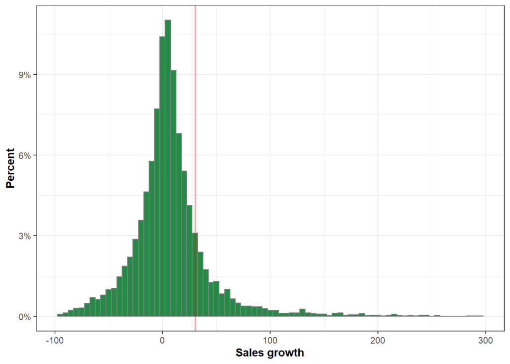

```r
# Histogram of sales growth

ggplot( data %>% filter(sales_growth_2 < 300)  , aes(x = sales_growth_2)) +
    geom_histogram( aes(y = (..count..)/sum(..count..)), binwidth = 5, fill="#238b45", color = 'gray50', na.rm = T) +
    geom_vline(xintercept=30, color = "red") +
    labs(y = 'Percent',x = "Sales growth" ) +
    scale_y_continuous(labels = scales::percent_format(1)) +
    theme_bw() +
    theme(
      plot.title = element_text(size = 12L,
                                face = "bold", hjust = 0.5),
      axis.title.y = element_text(face = "bold"),
      axis.title.x = element_text(face = "bold"),
      legend.position = "none")
```

```r
# Save
ggsave(paste0(output, "/sales_growth.jpg"), width = 4, height = 4)
```

The distribution is highly skewed with 7 firms having over 1000% annual growth rate.

In order to create a flag for fast growing firms from the annual growth we needed to set a threshold value. For this we examined the percentiles of the distribution.

```r
# Summary statistics of sales growth
P60 <- function(x){quantile(x,0.60,na.rm=T)}
P65 <- function(x){quantile(x,0.65,na.rm=T)}
P70 <- function(x){quantile(x,0.70,na.rm=T)}
P75 <- function(x){quantile(x,0.75,na.rm=T)}
P80 <- function(x){quantile(x,0.80,na.rm=T)}
P85 <- function(x){quantile(x,0.85,na.rm=T)}
P90 <- function(x){quantile(x,0.90,na.rm=T)}
P95 <- function(x){quantile(x,0.95,na.rm=T)}
P05 <- function(x){quantile(x,0.05,na.rm=T)}
# Range <- function(x){max(x, na.rm = TRUE) - min(x, na.rm = TRUE)}
Missing <- function(x){sum(is.na(x))}
Mean2 <- function(x){mean(x,na.rm=T)}

t <- datasummary(  (sales_growth_2)  ~
    (N + Missing + Mean2 + SD + Min + Max + P05 + Median  + P60 + P65 + P70 + P75 + P80 + P85 + P90 + P95),
    data = data,
    title = 'Descriptive statistics of growth rate' ) %>%
    kableExtra::kable_styling(latex_options = "hold_position", font_size = 10)
t
```

Descriptive statistics of growth rate

|  | N | Missing | Mean2 | SD | Min | Max | P05 | Median | P60 | P65 | P70 | P75 | P80 | P85 | P90 | P95 |
| --- | --- | --- | --- | --- | --- | --- | --- | --- | --- | --- | --- | --- | --- | --- | --- | --- |
| sales_growth_2 | 11949 | 0.00 | 10.62 | 59.71 | -95.76 | 1965.31 | -45.52 | 4.30 | 9.18 | 11.93 | 15.34 | 19.58 | 24.77 | 32.10 | 45.03 | 74.07 |

```r
# Save
cat(t,file= paste0(output, "/sales_growth_descriptives.tex"))

rm(t, P05, P60, P65, P70, P75, P80, P85, P90, P95, Mean2, Missing)
```

The mean growth rate is 10.62%. From the percentiles we can see that using the mean as cutoff value about 35-40% of the firms would be in the ‘fast growing’ group. With 25% growth rate roughly 20% of the firms would be classified as fast growing and with 30% about 15%. For classification it is needed to have enough observations in each group so I chose 30% as a round cutoff value.

In the sample 1954 observations were assigned the fast growing flag and 9995 had below 30% annual growth rate in the examined period.

```r
# Number of fast growing firms in the sample
kable(data %>% group_by(fast_growing_flg) %>%  dplyr::summarize(count = n())) %>%
  kable_styling(font_size = 11, full_width = F) %>%
  scroll_box(width = "900px")
```

| fast_growing_flg | count |
| --- | --- |
| 0 | 9995 |
| 1 | 1954 |

### 3.3. Feature engineering

Our variables of interest were grouped into three main groups. First of all the financial indicators of the firms including key balance sheet and profit and loss statements (P&L) items were considered as crucial predictors of the firms’ growth. Next, characteristics of the firm were also considered as important predictors of the company success. Finally information about the leadership and other HR related variables were also added to the analysis.

The following table summarizes the variables used in the analysis.

Table 1: Variable list

| Variable | Group |
| --- | --- |
| comp_id | ID |
| fast_growing_flg | Outcome |
| curr_assets | Financial variables - Raw |
| curr_liab | Financial variables - Raw |
| extra_exp | Financial variables - Raw |
| extra_inc | Financial variables - Raw |
| extra_profit_loss | Financial variables - Raw |
| fixed_assets | Financial variables - Raw |
| inc_bef_tax | Financial variables - Raw |
| intang_assets | Financial variables - Raw |
| inventories | Financial variables - Raw |
| liq_assets | Financial variables - Raw |
| material_exp | Financial variables - Raw |
| personnel_exp | Financial variables - Raw |
| profit_loss_year | Financial variables - Raw |
| sales | Financial variables - Raw |
| share_eq | Financial variables - Raw |
| subscribed_cap | Financial variables - Raw |
| balsheet_flag | Financial variables - Quality |
| balsheet_length | Financial variables - Quality |
| balsheet_notfullyear | Financial variables - Quality |
| total_assets_bs | Financial variables - ratios, winsorized |
| extra_exp_pl | Financial variables - ratios, winsorized |
| extra_inc_pl | Financial variables - ratios, winsorized |
| extra_profit_loss_pl | Financial variables - ratios, winsorized |
| inc_bef_tax_pl | Financial variables - ratios, winsorized |
| inventories_pl | Financial variables - ratios, winsorized |
| material_exp_pl | Financial variables - ratios, winsorized |
| profit_loss_year_pl | Financial variables - ratios, winsorized |
| personnel_exp_pl | Financial variables - ratios, winsorized |

[output cut: 58 more lines]

The data wrangling steps of the predictors are summarized below.

In case of the predictors of the firm characteristics the following variables were considered:

- The age of the firm and its square which were calculated from the year of foundation.
- Factor variables were created for the region of the firm, for its city type (capital city, big city or other) and for the gender categorization of the firms.
- Industry categories were merged to create less granular categories.

For the financial variables more data cleaning steps were needed in order to ensure better data quality:

- Asset side variables (intang_assets, curr_assets, fixed_assets) with negative values were floored at 0 as they cannot be negative. Flag for assets with negative value was added to measure the quality of the financial variables.
- Total assets were calculated from the asset side items.
- Ratios were created from the asset side items normalized by the total asset (suffixed with ‘bs_’).
- Ratios were created from the P&L items normalized by the sales value (suffixed with ‘pl_’).
- Financial ratios calculated from financial items that cannot be negative were winsorized to have values between (0, 1). Flags were created in order to track the corrections.
- Financial ratios calculated from financial items that can be negative were winsorized to have values between (-1, 1]) Flags were created in order to track the corrections.
- Quadratics of the latter financial indicators were calculated.

Finally, in case of the HR / Leadership related variables data imputation was necessary because of the relatively high missing rate.

- The age of the CEO was calculated from the birth year of the CEO and missings were replaced by the mean age. CEOs below the age of 25 years were assigned 25 and CEOs above 75 years were assigned 75 years. Flags were added to capture field quality.
- The missing number of employees information (labor_avg_mod) was replaced by the mean number of employees.
- Flag indicating whether the company has foreign management (foreign_management) was assigned 1 if the the proportion of foreign CEOs exceeded 50%.

```r
# A. Create variable groups

# Raw financial variables
rawvars <-  c("curr_assets", "curr_liab", "extra_exp", "extra_inc", "extra_profit_loss", "fixed_assets",
              "inc_bef_tax", "intang_assets", "inventories", "liq_assets", "material_exp", "personnel_exp",
              "profit_loss_year", "share_eq", "subscribed_cap")

# Quality vars - FInancials
qualityvars <- c(  "balsheet_length", "balsheet_notfullyear")
# "balsheet_flag",

# Financial ratios
engvar <- c("total_assets_bs", "fixed_assets_bs", "liq_assets_bs", "curr_assets_bs",
            "share_eq_bs", "subscribed_cap_bs", "intang_assets_bs", "extra_exp_pl",
            "extra_inc_pl", "extra_profit_loss_pl", "inc_bef_tax_pl", "inventories_pl",
            "material_exp_pl", "profit_loss_year_pl", "personnel_exp_pl")

# Squared financial items
engvar2 <- c("extra_profit_loss_pl_quad", "inc_bef_tax_pl_quad",
             "profit_loss_year_pl_quad", "share_eq_bs_quad")

# Data quality flags - Financial ratios
engvar3 <- c(grep("*flag_low$", names(data), value = TRUE),
             grep("*flag_high$", names(data), value = TRUE),
             grep("*flag_error$", names(data), value = TRUE),
             grep("*flag_zero$", names(data), value = TRUE))


# Human capital related variables
hr <- c("female", "ceo_age", "flag_high_ceo_age", "flag_low_ceo_age",
        "flag_miss_ceo_age", "ceo_count", "labor_avg_mod",
        "flag_miss_labor_avg", "foreign_management")


# Firms related variables
firm <- c("age", "age2", "ind2_cat", "m_region_loc", "urban_m")

# Interactions for logit, LASSO
interactions1 <- c("ind2_cat*age", "ind2_cat*age2",
                   "ind2_cat*d1_sales_mil_log_mod", "ind2_cat*sales_mil_log",
                   "ind2_cat*ceo_age", "ind2_cat*foreign_management",
                   "ind2_cat*female",   "ind2_cat*urban_m", "ind2_cat*labor_avg_mod")

# More interactions
interactions2 <- c("sales_mil_log*age", "sales_mil_log*female",
                   "sales_mil_log*profit_loss_year_pl", "sales_mil_log*foreign_management")


# B. Define models

# Define models for Logit
X1 <- c("sales_mil_log", "sales_mil_log_sq", "d1_sales_mil_log_mod", "profit_loss_year_pl", "ind2_cat")
X2 <- c("sales_mil_log", "sales_mil_log_sq", "d1_sales_mil_log_mod", "profit_loss_year_pl", "fixed_assets_bs","share_eq_bs","curr_liab_bs ",   "curr_liab_bs_flag_high ", "curr_liab_bs_flag_error",  "age","foreign_management" , "ind2_cat")
X3 <- c("sales_mil_log", "sales_mil_log_sq", firm, engvar)
X4 <- c("sales_mil_log", "sales_mil_log_sq", firm, engvar, engvar2, engvar3, hr, qualityvars)
X5 <- c("sales_mil_log", "sales_mil_log_sq", firm, engvar, engvar2, engvar3, hr, qualityvars, interactions1, interactions2)

# Define model for LASSO (incl. interactions, polynomials)
logitvars <- c("sales_mil_log", "sales_mil_log_sq", engvar, engvar2, engvar3, hr, firm, qualityvars, interactions1, interactions2)

# Define model for RF (no interactions, no modified features)
# rfvars  <-  c("sales_mil_log", "sales_mil_log_sq", engvar, engvar2, engvar3, hr, firm, qualityvars)
rfvars  <-  c("sales_mil", "d1_sales_mil_log", rawvars, hr, firm, qualityvars)
```

## 4. EDA

Before we start to build the prediction models let’s take a look at the relationship between our key financial variables and the firm success indicator.

#### 4.1. Relationship with raw financial variables

The relationship is mostly U-shaped with the asset side items. Only in case of the extra profit and loss we can see inversepattern.

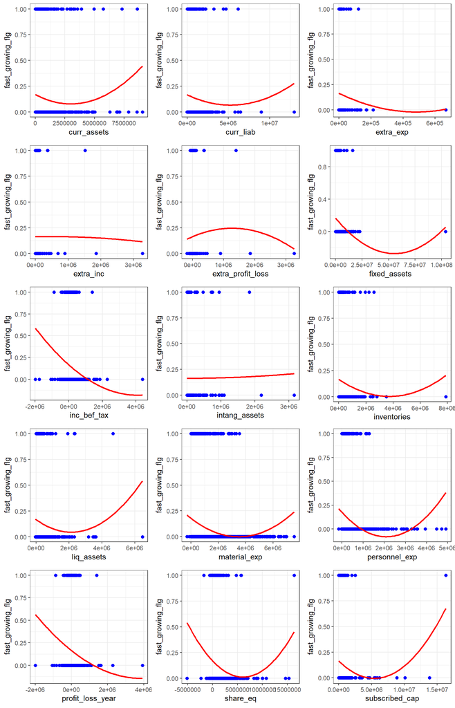

```r
# Create df

data_m <- data %>% dplyr::select("fast_growing_flg", rawvars)

plot_for_loop <- function(df, .x_var, .y_var) {

  x_var <- sym(.x_var)
  y_var <- sym(.y_var)

  ggplot(df, aes(x = !! y_var, y = !! x_var)) +
    geom_point(size=0.5,  shape=20, stroke=2, fill="blue", color="blue") +
      geom_smooth(method = "lm", formula = y ~ poly(x,2), se = F, size=1, color = "red")+
    # ylim(c(0,1)) +
    labs(x = y_var, y = x_var) +
    theme_bw()
}

plot_list <- colnames(data_m)[-1] %>%
  map( ~ plot_for_loop(data_m, colnames(data_m)[1], .x))


plot_grid(plotlist = plot_list, ncol = 3)
```

```r
# Summary statistics
# datasummary( (curr_assets+ curr_liab+ extra_exp+ extra_inc+ extra_profit_loss+ fixed_assets+
#               inc_bef_tax+ intang_assets+ inventories+ liq_assets+ material_exp+ personnel_exp+
#               profit_loss_year+ sales+ share_eq+ subscribed_cap    ) ~ mean * ( recode_factor( fast_growing_flg, `1` = "Fast growing", `0` = "Not fast growing") ),data)
```

#### 4.2. Relationship with financial ratios

In case of the normalized financial indicators the relationship seems to be more linear for the asset side items. In case of the P&L items the U-shaped relationship remained.

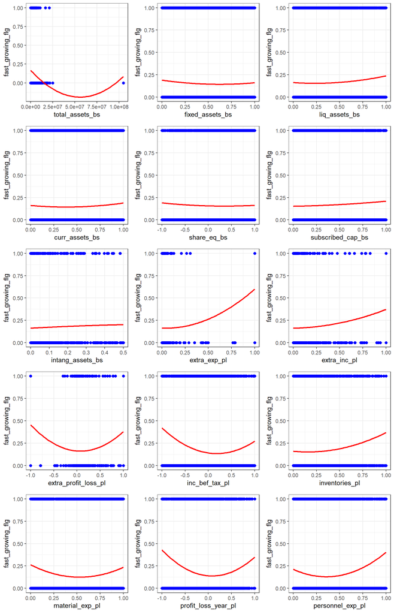

```r
# Create df
data_m <- data %>% select("fast_growing_flg", engvar)

plot_for_loop <- function(df, .x_var, .y_var) {

  x_var <- sym(.x_var)
  y_var <- sym(.y_var)

  ggplot(df, aes(x = !! y_var, y = !! x_var)) +
    geom_point(size=0.5,  shape=20, stroke=2, fill="blue", color="blue") +
      geom_smooth(method = "lm", formula = y ~ poly(x,2), se = F, size=1, color = "red")+
    # ylim(c(0,1)) +
    labs(x = y_var, y = x_var) +
    theme_bw()
}

plot_list <- colnames(data_m)[-1] %>%
  map( ~ plot_for_loop(data_m, colnames(data_m)[1], .x))


plot_grid(plotlist = plot_list, ncol = 3)
```

#### 4.3. Relationship with log sales, number of employees

The next charts show the relationship of the sales growth with the log sales, the lagged change in sales and the number of employees. It seems that companies with smaller sales or decreasing sales have higher probability to grow faster as well as companies with the highest sales and the pattern changes at around 1 million EUR.

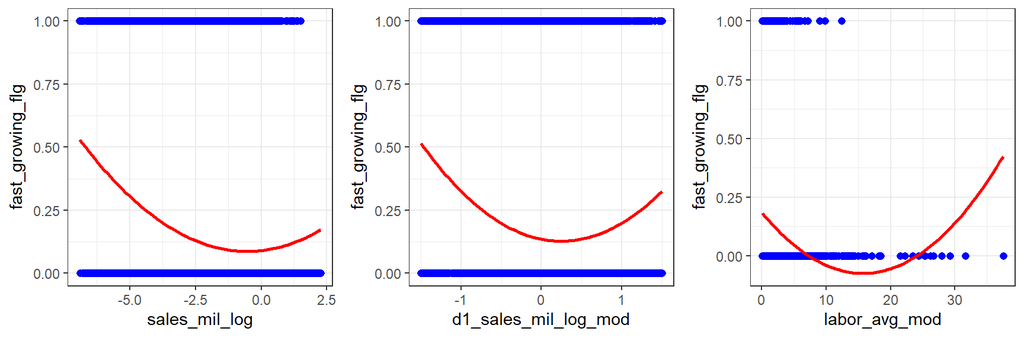

```r
# Create df
data_m <- data %>% select("fast_growing_flg","sales_mil_log", "d1_sales_mil_log_mod", "labor_avg_mod")

plot_for_loop <- function(df, .x_var, .y_var) {

  x_var <- sym(.x_var)
  y_var <- sym(.y_var)

  ggplot(df, aes(x = !! y_var, y = !! x_var)) +
    geom_point(size=0.5,  shape=20, stroke=2, fill="blue", color="blue") +
      geom_smooth(method = "lm", formula = y ~ poly(x,2), se = F, size=1, color = "red")+
    # ylim(c(0,1)) +
    labs(x = y_var, y = x_var) +
    theme_bw()
}

plot_list <- colnames(data_m)[-1] %>%
  map( ~ plot_for_loop(data_m, colnames(data_m)[1], .x))


plot_grid(plotlist = plot_list, ncol = 3)
```

## 5. Modelling

For the modelling, train and holdout sets were created by randomly splitting the dataset into two partitions. 80% of the firms (9560 observations) were added to the train set and 20% of the firms (2389 observations) were kept for the holdout set. In case of all the presented models the modelling was done on the train set and the performance of the selected models were evaluated on the holdout set.

```r
# Create train and holdout samples
train_indices <- as.integer(createDataPartition(data$fast_growing_f, p = 0.8, list = FALSE))
data_train    <- data[train_indices, ]
data_holdout  <- data[-train_indices, ]
```

```r
# Number of observations in the sets
data_train %>% group_by(fast_growing_flg) %>% summarize(count = n())
```

```
## # A tibble: 2 x 2
##   fast_growing_flg count
##              <dbl> <int>
## 1                0  7996
## 2                1  1564
```

```r
data_holdout %>% group_by(fast_growing_flg) %>% summarize(count = n())
```

```
## # A tibble: 2 x 2
##   fast_growing_flg count
##              <dbl> <int>
## 1                0  1999
## 2                1   390
```

The proportion of fast growing firms is about 16% and this proportion is stable accross the train and holdout samples.

```r
# Proportion of fast growing firms by total, train and holdout samples
Hmisc::describe(data$fast_growing_f)
```

```
## data$fast_growing_f
##        n  missing distinct
##    11949        0        2
##
## Value      not_fast_growing     fast_growing
## Frequency              9995             1954
## Proportion            0.836            0.164
```

```r
Hmisc::describe(data_train$fast_growing_f)
```

```
## data_train$fast_growing_f
##        n  missing distinct
##     9560        0        2
##
## Value      not_fast_growing     fast_growing
## Frequency              7996             1564
## Proportion            0.836            0.164
```

```r
Hmisc::describe(data_holdout$fast_growing_f)
```

```
## data_holdout$fast_growing_f
##        n  missing distinct
##     2389        0        2
##
## Value      not_fast_growing     fast_growing
## Frequency              1999              390
## Proportion            0.837            0.163
```

### 5.1. Model estimation

Our final goal is to build a prediction model based on the observable firm data which is able to predict fast growing companies in the future. For this, first we will develop Logit, LASSO and Random forest models and compare their performance. Then we will make predictions using the selected model(s) and apply a loss function to make a decision about the threshold of growth of the firms that minimizes the expected loss.

The following table summarizes the predictors included in each model specification:

[output not shown]

#### 5.1.1. Logit models

We started the analysis with the simplest Logit specification which only included the sales, P&L and industry information of the firms. Then we enriched the model with more predictors including asset side items, equity and liabilities items, HR and firm related information. For Model 4 and 5 normalized financial indicators were used instead of the raw balance sheet and P&L items and interaction terms were added to the models.

```r
# Define placeholder for model results
CV_RMSE_folds <- list()
logit_models <- list()
all_models <- list()

# Set train control
train_control <- trainControl(
  method = "cv",
  number = 5,
  classProbs = TRUE,
  summaryFunction = twoClassSummaryExtended,
  savePredictions = TRUE
)

# List of logit models
logit_model_vars <- list("X1" = X1, "X2" = X2, "X3" = X3, "X4" = X4, "X5" = X5)

# Run models
for (model_name in names(logit_model_vars)) {

  # setting the variables for each model
  features <- logit_model_vars[[model_name]]

  # Estimate logit model with 5-fold CV
  set.seed(123456)
  ({glm_model <- train(
    formula(paste0("fast_growing_f ~", paste0(features, collapse = " + "))),
    method    = "glm",
    data      = data_train,
    family    = binomial,
    trControl = train_control
  )})

  # Save the results to list
  logit_models[[model_name]] <- glm_model
  all_models[[model_name]] <- glm_model
  # Save RMSE on test for each fold
  CV_RMSE_folds[[model_name]] <- glm_model$resample[,c("Resample", "RMSE")]

}

# CV_RMSE_folds
```

#### 5.1.2. Logit model with LASSO

Next, Logit model with LASSO was used in which all the variables (including the interaction terms and the polynomials) were included.

```r
# Set lambda parameters to check
lambda <- 10^seq(-1, -4, length = 10)
grid <- expand.grid("alpha" = 1, lambda = lambda)

# Estimate logit + LASSO with 5-fold CV to find lambda
set.seed(123456)
({
  logit_lasso_model <- train(
    formula(paste0("fast_growing_f ~", paste0(logitvars, collapse = " + "))),
    data = data_train,
    method = "glmnet",
    preProcess = c("center", "scale"),
    family = "binomial",
    trControl = train_control,
    tuneGrid = grid,
    na.action=na.exclude
  )
})
```

```
## glmnet
##
## 9560 samples
##   65 predictor
##    2 classes: 'not_fast_growing', 'fast_growing'
##
## Pre-processing: centered (202), scaled (202)
## Resampling: Cross-Validated (5 fold)
## Summary of sample sizes: 7648, 7649, 7648, 7647, 7648
## Resampling results across tuning parameters:
##
##   lambda        Accuracy   Kappa       RMSE
##   0.0001000000  0.8396432  0.12058434  0.3562797
##   0.0002154435  0.8401663  0.12232123  0.3560390
##   0.0004641589  0.8402710  0.11717746  0.3555485
##   0.0010000000  0.8397480  0.10414692  0.3550673
##   0.0021544347  0.8411084  0.10160720  0.3546304
##   0.0046415888  0.8415270  0.08963631  0.3542432
##   0.0100000000  0.8407946  0.06763662  0.3549362
##   0.0215443469  0.8380754  0.01949942  0.3578233
##   0.0464158883  0.8364017  0.00000000  0.3637006
##   0.1000000000  0.8364017  0.00000000  0.3699106
##
## Tuning parameter 'alpha' was held constant at a value of 1
## Accuracy was used to select the optimal model using the largest value.
## The final values used for the model were alpha = 1 and lambda = 0.004641589.
```

```r
# Save the results
tuned_logit_lasso_model <- logit_lasso_model$finalModel
best_lambda <- logit_lasso_model$bestTune$lambda
logit_models[["LASSO"]] <- logit_lasso_model
all_models[["LASSO"]] <- logit_lasso_model
lasso_coeffs <- as.matrix(coef(tuned_logit_lasso_model, best_lambda))
CV_RMSE_folds[["LASSO"]] <- logit_lasso_model$resample[,c("Resample", "RMSE")]
```

#### 5.1.3. Random forest model

Finally, Random forest model was also estimated and its performance was compared to the other 6 models.

```r
# Set train control - 5-fold CV
train_control <- trainControl(
  method = "cv",
  n = 5,
  classProbs = TRUE, # same as probability = TRUE in ranger
  summaryFunction = twoClassSummaryExtended,
  savePredictions = TRUE
)

train_control$verboseIter <- TRUE

tune_grid <- expand.grid(
  .mtry = 5, # c(5, 6, 7),
  .splitrule = "gini",
  .min.node.size = 15 # c(10, 15)
)

set.seed(123456)
({rf_model_p <- train(
  formula(paste0("fast_growing_f ~ ", paste0(rfvars , collapse = " + "))),
  method = "ranger",
  data = data_train,
  tuneGrid = tune_grid,
  trControl = train_control
)})
```

```
## Random Forest
##
## 9560 samples
##   33 predictor
##    2 classes: 'not_fast_growing', 'fast_growing'
##
## No pre-processing
## Resampling: Cross-Validated (5 fold)
## Summary of sample sizes: 7648, 7649, 7648, 7647, 7648
## Resampling results:
##
##   Accuracy   Kappa     RMSE
##   0.8430961  0.107384  0.3521528
##
## Tuning parameter 'mtry' was held constant at a value of 5
## Tuning
##  parameter 'splitrule' was held constant at a value of gini
## Tuning
##  parameter 'min.node.size' was held constant at a value of 15
```

```r
# rf_model_p$results
best_mtry <- rf_model_p$bestTune$mtry
best_min_node_size <- rf_model_p$bestTune$min.node.size

# Get average (ie over the folds) RMSE and AUC
CV_RMSE_folds[["rf_p"]] <- rf_model_p$resample[,c("Resample", "RMSE")]
all_models[["rf_p"]] <- rf_model_p
```

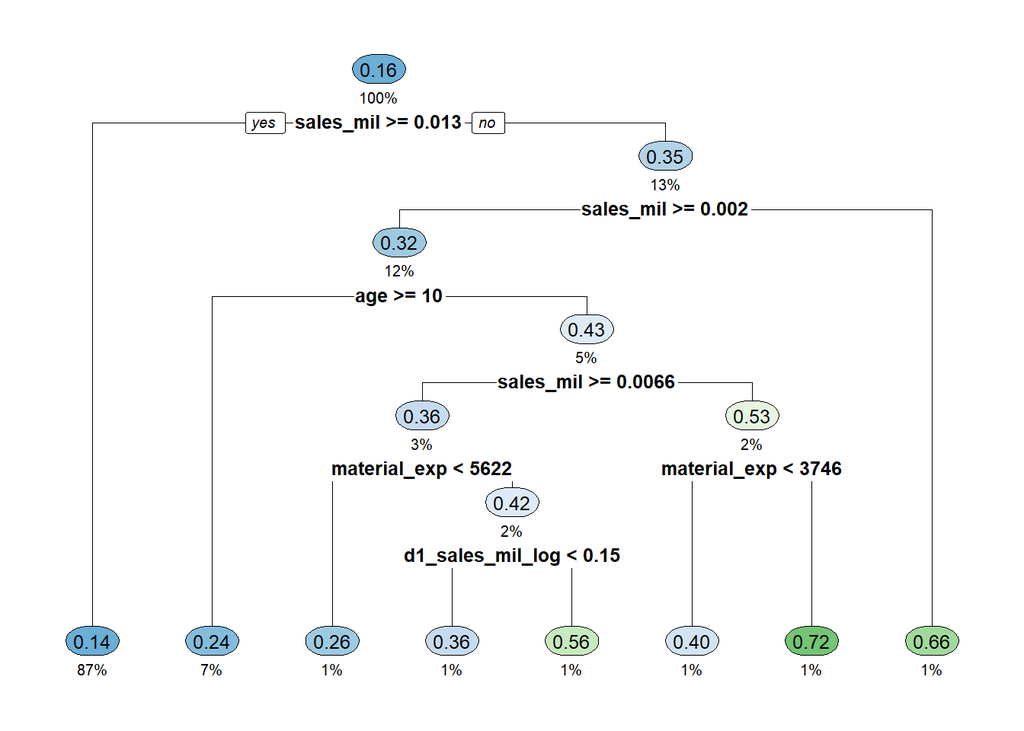

```r
data_for_graph <- data_train
levels(data_for_graph$fast_growing_f) <- list("stay" = "not_fast_growing", "exit" = "fast_growing")

set.seed(123456)
rf_for_graph <-
  rpart(
    formula(paste0("fast_growing_f ~ ", paste0(rfvars , collapse = " + "))),
    data = data_for_graph,
    control = rpart.control(cp = 0.001, minbucket = 50)
  )

rpart.plot(rf_for_graph, tweak=1, digits=2, extra=107, under = TRUE)
```

```r
# save_tree_plot(rf_for_graph, "tree_plot", output, "small", tweak=1)
```

### 5.2. Model comparison based on cross-validated RMSE and AUC

Now that we have the estimates for all models we can compare their performance based on the cross-validated RMSE and the AUC.

```r
# AUC and RMSE CV - by folds and average

# Calculate AUC for each fold
CV_AUC_folds <- list()

for (model_name in names(all_models)) {

  auc <- list()
  model <- all_models[[model_name]]
  for (fold in c("Fold1", "Fold2", "Fold3", "Fold4", "Fold5")) {
    # get the prediction from each fold
    cv_fold <-
      model$pred %>%
      filter(Resample == fold)
    # calculate the roc curve
    roc_obj <- roc(cv_fold$obs, cv_fold$fast_growing, quiet = TRUE)
    # save the AUC value
    auc[[fold]] <- as.numeric(roc_obj$auc)
  }

  CV_AUC_folds[[model_name]] <- data.frame("Resample" = names(auc),
                                              "AUC" = unlist(auc))
}

# For each model: calculate average RMSE and average AUC for models
CV_RMSE <- list()
CV_AUC <- list()

for (model_name in names(all_models)) {
  CV_RMSE[[model_name]] <- mean(CV_RMSE_folds[[model_name]]$RMSE)
  CV_AUC[[model_name]] <- mean(CV_AUC_folds[[model_name]]$AUC)
}

# CV_RMSE
# CV_AUC
```

The RF model outperforms all other models based on both the cross-validated RMSE and the AUC. If we would like to have a simpler model we can also decide between Model 4 (highest AUC among the logit models) or the logit with LASSO (lowest RMSE among the logit models).

```r
# Compare models based on train CV RMSE and AUC

nvars <- lapply(all_models, FUN = function(x) length(x$coefnames))
nvars[["LASSO"]] <- sum(lasso_coeffs != 0)

CV_AUC_summary <- data.frame("Number of predictors" = unlist(nvars),
                             "CV RMSE" = unlist(CV_RMSE),
                             "CV AUC" = unlist(CV_AUC))

# Summarize
row.names(CV_AUC_summary) <- c("Logit M1","Logit M2","Logit M3","Logit M4","Logit M5","LASSO","Random forest")
colnames(CV_AUC_summary) <- c("Number of predictors","CV RMSE","CV AUC")
CV_AUC_summary
```

```
##               Number of predictors   CV RMSE    CV AUC
## Logit M1                        16 0.3586676 0.6543796
## Logit M2                        23 0.3552117 0.6750967
## Logit M3                        35 0.3550360 0.6824612
## Logit M4                        77 0.3551965 0.6864103
## Logit M5                       202 0.3569479 0.6818848
## LASSO                           43 0.3542432 0.6649997
## Random forest                   46 0.3521528 0.7003074
```

```r
# Check stabilty of results by folds
# CV_RMSE_folds[7]
# CV_AUC_folds[7]

# Save
kable(x = CV_AUC_summary, format = "latex", booktabs=TRUE,  digits = 3, row.names = TRUE,
      linesep = "", col.names = c("Number of predictors","CV RMSE","CV AUC")) %>%
  cat(.,file= paste0(output, "/CV_AUC_summary.tex"))
```

### 5.3. Probability prediction (with best model based on CV RMSE and AUC)

Let’s predict the probability of being a fast growing using the chosen Logit model and the random forest model.

#### 5.3.1. Calibration curve of best logit model

We can first predict the probability of success on the holdout sample and calculate the holdout RMSE.

```r
#  Estimate RMSE on holdout sample (with the selected model specification)
best_logit_no_loss <- logit_models[["X3"]]

logit_predicted_probabilities_holdout    <- predict(best_logit_no_loss, newdata = data_holdout, type = "prob")
data_holdout[,"best_logit_no_loss_pred"] <- logit_predicted_probabilities_holdout[,"fast_growing"]
RMSE(data_holdout[, "best_logit_no_loss_pred", drop=TRUE], data_holdout$fast_growing_flg)
```

```
## [1] 0.3582339
```

```r
# Calibration curve
jpeg(paste0(output, "/calibration_curve_logit.jpg"))
create_calibration_plot(data_holdout,
                        prob_var = "best_logit_no_loss_pred",
                        actual_var = "fast_growing_flg",
                        n_bins = 10)
dev.off()
```

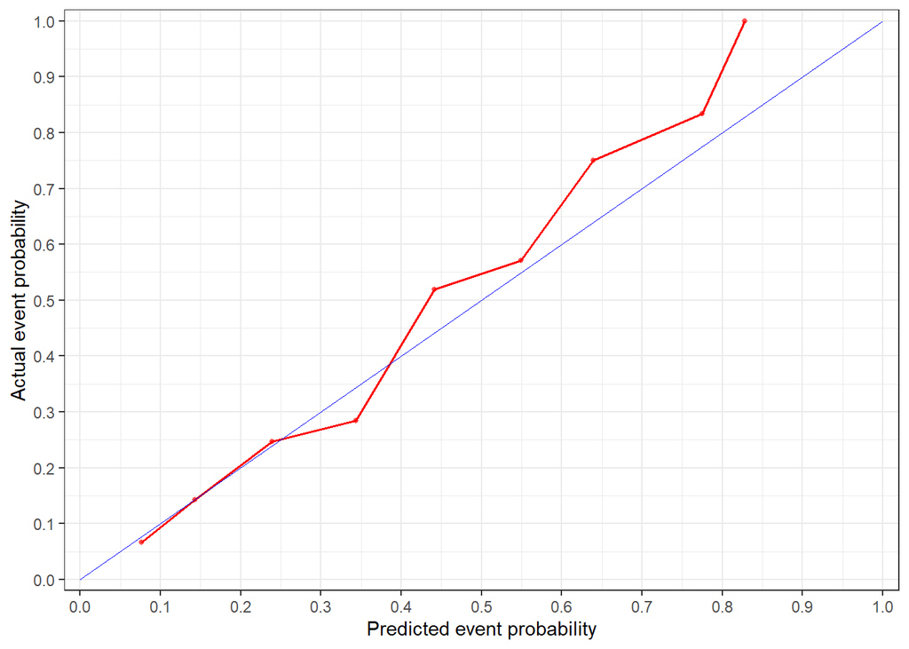

```r
create_calibration_plot(data_holdout,
                        prob_var = "best_logit_no_loss_pred",
                        actual_var = "fast_growing_flg",
                        n_bins = 10)
```

#### 5.3.2. Calibration curve of Random forest model

```r
#  Estimate RMSE on holdout sample
rf_model_pred <- all_models[["rf_p"]]

rf_predicted_probabilities_holdout    <- predict(rf_model_pred, newdata = data_holdout, type = "prob")
data_holdout[,"rf_model_pred"] <- rf_predicted_probabilities_holdout[,"fast_growing"]
RMSE(data_holdout[, "rf_model_pred", drop=TRUE], data_holdout$fast_growing_flg)
```

```
## [1] 0.351812
```

```r
# Calibration curve
jpeg(paste0(output, "/calibration_curve_rf.jpg"))
create_calibration_plot(data_holdout,
                        prob_var = "rf_model_pred",
                        actual_var = "fast_growing_flg",
                        n_bins = 10)
dev.off()
```

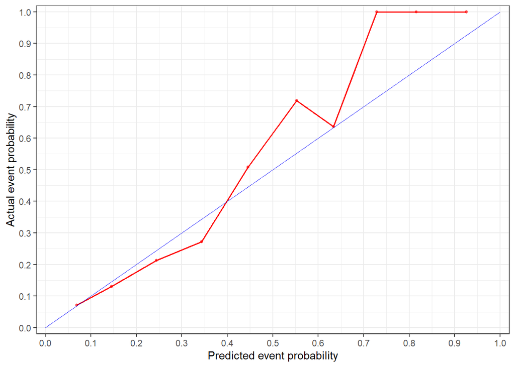

```r
create_calibration_plot(data_holdout,
                        prob_var = "rf_model_pred",
                        actual_var = "fast_growing_flg",
                        n_bins = 10)
```

### 5.4. Classification with loss function

#### 5.4.1. Define loss function

Let’s define the loss function that we can use to map decisions to their associated costs. Our goal is to invest in companies that we expect to grow the fastest on the market with outstanding anticipated profitability prospects. Therefore if we lose the opportunity to invest in these firms because out model makes too conservative predictions about their future growth than it considerably deteriorates our future profitability. Of course, there is a risk that we invest in companies that were anticipated to grow above 30% but the sales grew below our expectations or even have negative growth rate. When we decide about the relative cost of these scenarios we need to consider that the potential gains of a good investment can be higher by a unit than the losses by investing less prosperous company. We will consider the relative cost of these two errors 4:1 indicating that the cost of making too conservative decision and losing the opportunity to invest in a prosperous firm is four times higher than making a risky investment.

```r
# Define loss function (FN/FP)
FP=1
FN=4
cost = FN/FP

# Proportion of cases in the population (n.cases/(n.controls+n.cases))
prevelance = sum(data_train$fast_growing_flg)/length(data_train$fast_growing_flg)
```

#### 5.4.2. Model comparison

##### 5.4.2.1. ROC curve and expected loss on train - Logit

```r
# Draw ROC Curve and find optimal threshold with loss function
best_tresholds <- list()
expected_loss <- list()
logit_cv_rocs <- list()
logit_cv_threshold <- list()
logit_cv_expected_loss <- list()

for (model_name in names(logit_models)) {

  model <- logit_models[[model_name]]
  colname <- paste0(model_name,"_prediction")

  best_tresholds_cv <- list()
  expected_loss_cv <- list()

  for (fold in c("Fold1", "Fold2", "Fold3", "Fold4", "Fold5")) {
    cv_fold <-
      model$pred %>%
      filter(Resample == fold)

    roc_obj <- roc(cv_fold$obs, cv_fold$fast_growing)
    best_treshold <- coords(roc_obj, "best", ret="all", transpose = FALSE,
                            best.method="youden", best.weights=c(cost, prevelance))
    best_tresholds_cv[[fold]] <- best_treshold$threshold
    expected_loss_cv[[fold]] <- (best_treshold$fp*FP + best_treshold$fn*FN)/length(cv_fold$fast_growing)
  }

  # average
  best_tresholds[[model_name]] <- mean(unlist(best_tresholds_cv))
  expected_loss[[model_name]] <- mean(unlist(expected_loss_cv))

  # for fold #5
  logit_cv_rocs[[model_name]] <- roc_obj
  logit_cv_threshold[[model_name]] <- best_treshold
  logit_cv_expected_loss[[model_name]] <- expected_loss_cv[[fold]]

  }

logit_summary2 <- data.frame("Avg of optimal thresholds" = unlist(best_tresholds),
                             "Threshold for Fold5" = sapply(logit_cv_threshold, function(x) {x$threshold}),
                             "Avg expected loss" = unlist(expected_loss),
                             "Expected loss for Fold5" = unlist(logit_cv_expected_loss))

kable(x = logit_summary2, format = "latex", booktabs=TRUE,  digits = 3, row.names = TRUE,
      linesep = "", col.names = c("Avg of optimal thresholds","Threshold for fold #5",
                                  "Avg expected loss","Expected loss for fold #5")) %>%
  cat(.,file= paste0(output, "/logit_optimal_threshold_EL.tex"))


logit_summary2
```

```
##       Avg.of.optimal.thresholds Threshold.for.Fold5 Avg.expected.loss
## X1                    0.2046171           0.2013656         0.5397487
## X2                    0.2279722           0.2273124         0.5248971
## X3                    0.2089431           0.1988679         0.5174678
## X4                    0.2280010           0.2110796         0.5102504
## X5                    0.2178462           0.1974040         0.5161111
## LASSO                 0.2065004           0.1972200         0.5388605
##       Expected.loss.for.Fold5
## X1                  0.5423640
## X2                  0.5209205
## X3                  0.5266736
## X4                  0.5324268
## X5                  0.5151674
## LASSO               0.5521444
```

##### 5.4.2.2. ROC curve and expected loss on train - Random forest

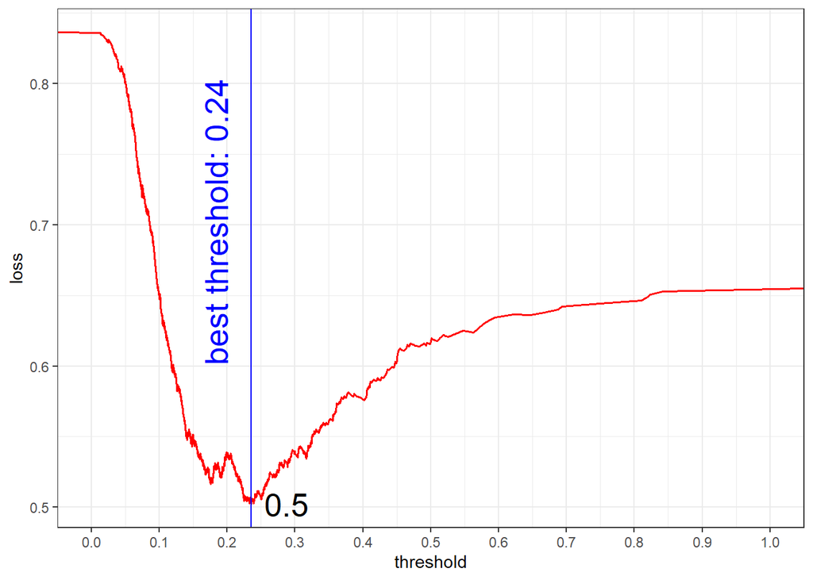

```r
# Now use loss function and search for best thresholds and expected loss over folds -----
best_tresholds_cv <- list()
expected_loss_cv <- list()

for (fold in c("Fold1", "Fold2", "Fold3", "Fold4", "Fold5")) {
  cv_fold <-
    rf_model_p$pred %>%
    filter(mtry == best_mtry,
           min.node.size == best_min_node_size,
           Resample == fold)

  roc_obj <- roc(cv_fold$obs, cv_fold$fast_growing)
  best_treshold <- coords(roc_obj, "best", ret="all", transpose = FALSE,
                          best.method="youden", best.weights=c(cost, prevelance))
  best_tresholds_cv[[fold]] <- best_treshold$threshold
  expected_loss_cv[[fold]] <- (best_treshold$fp*FP + best_treshold$fn*FN)/length(cv_fold$fast_growing)
}

# average
best_tresholds[["rf_p"]] <- mean(unlist(best_tresholds_cv))
expected_loss[["rf_p"]] <- mean(unlist(expected_loss_cv))


rf_summary <- data.frame("CV RMSE" = CV_RMSE[["rf_p"]],
                         "CV AUC" = CV_AUC[["rf_p"]],
                         "Avg of optimal thresholds" = best_tresholds[["rf_p"]],
                         "Threshold for Fold5" = best_treshold$threshold,
                         "Avg expected loss" = expected_loss[["rf_p"]],
                         "Expected loss for Fold5" = expected_loss_cv[[fold]])

kable(x = rf_summary, format = "latex", booktabs=TRUE,  digits = 3, row.names = TRUE,
      linesep = "", col.names = c("CV RMSE", "CV AUC",
                                  "Avg of optimal thresholds","Threshold for fold #5",
                                  "Avg expected loss","Expected loss for fold #5")) %>%
  cat(.,file= paste0(output, "/rf_summary.tex"))

# Create plots - this is for Fold5

createLossPlot(roc_obj, best_treshold, "rf_p_loss_plot")
```

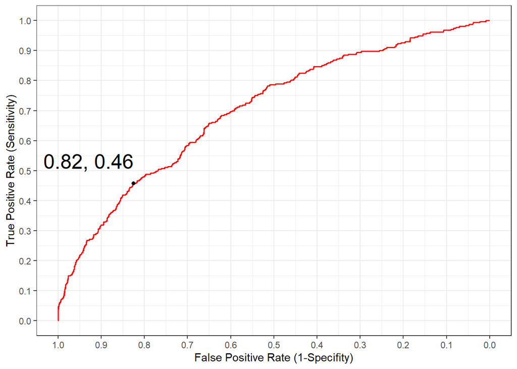

```r
createRocPlotWithOptimal(roc_obj, best_treshold, "rf_p_roc_plot")
```

##### 5.4.2.3. Compare model performance based on expected loss

```r
# Summary results

nvars[["rf_p"]] <- length(rfvars)

summary_results <- data.frame("Number of predictors" = unlist(nvars),
                              "CV RMSE" = unlist(CV_RMSE),
                              "CV AUC" = unlist(CV_AUC),
                              "CV threshold" = unlist(best_tresholds),
                              "CV expected Loss" = unlist(expected_loss))

model_names <- c("Logit X1", "Logit X2","Logit X3", "Logit X4", "Logit X5",
                 "Logit LASSO","RF probability")
summary_results <- summary_results %>%
  filter(rownames(.) %in% c("X1", "X2", "X3","X4", "X5", "LASSO", "rf_p"))
rownames(summary_results) <- model_names

kable(x = summary_results, format = "latex", booktabs=TRUE,  digits = 3, row.names = TRUE,
      linesep = "", col.names = c("Number of predictors", "CV RMSE", "CV AUC",
                                  "CV threshold", "CV expected Loss")) %>%
  cat(.,file= paste0(output, "/summary_results.tex"))


summary_results
```

```
##                Number.of.predictors   CV.RMSE    CV.AUC CV.threshold
## Logit X1                         16 0.3586676 0.6543796    0.2046171
## Logit X2                         23 0.3552117 0.6750967    0.2279722
## Logit X3                         35 0.3550360 0.6824612    0.2089431
## Logit X4                         77 0.3551965 0.6864103    0.2280010
## Logit X5                        202 0.3569479 0.6818848    0.2178462
## Logit LASSO                      43 0.3542432 0.6649997    0.2065004
## RF probability                   33 0.3521528 0.7003074    0.2347886
##                CV.expected.Loss
## Logit X1              0.5397487
## Logit X2              0.5248971
## Logit X3              0.5174678
## Logit X4              0.5102504
## Logit X5              0.5161111
## Logit LASSO           0.5388605
## RF probability        0.4995823
```

#### 5.4.3. Model evaluation

##### 5.4.3.1. ROC curve and expected loss on holdout - Logit

```r
# Pick best model based on average expected loss in train
best_logit_with_loss <- logit_models[["X4"]]
best_logit_optimal_treshold <- best_tresholds[["X4"]]

logit_predicted_probabilities_holdout <- predict(best_logit_with_loss, newdata = data_holdout, type = "prob")
data_holdout[,"best_logit_with_loss_pred"] <- logit_predicted_probabilities_holdout[,"fast_growing"]
```

```r
# ROC curve on holdout

# ROC curve on holdout
roc_obj_holdout <- roc(data_holdout$fast_growing_flg, data_holdout[, "best_logit_with_loss_pred", drop=TRUE])

# Get expected loss on holdout
holdout_treshold <- coords(roc_obj_holdout, x = best_logit_optimal_treshold, input= "threshold",
                           ret="all", transpose = FALSE)

expected_loss_holdout <- (holdout_treshold$fp*FP + holdout_treshold$fn*FN)/length(data_holdout$fast_growing_flg)
expected_loss_holdout
```

```
## [1] 0.552951
```

##### 5.4.3.2. Confusion matrix on holdout - Logit

```r
# Confusion table on holdout with optimal threshold
holdout_prediction <-
  ifelse(data_holdout$best_logit_with_loss_pred < best_logit_optimal_treshold, "not_fast_growing", "fast_growing") %>%
  factor(levels = c("not_fast_growing", "fast_growing"))
cm_object3 <- confusionMatrix(holdout_prediction,data_holdout$fast_growing_f)
cm3 <- cm_object3$table
cm3
```

```
##                   Reference
## Prediction         not_fast_growing fast_growing
##   not_fast_growing             1682          251
##   fast_growing                  317          139
```

##### 5.4.2.3. ROC curve and expected loss on holdout - Random forest

```r
# Take model to holdout and estimate RMSE, AUC and expected loss ------------------------------------

rf_predicted_probabilities_holdout <- predict(rf_model_p, newdata = data_holdout, type = "prob")
data_holdout$rf_p_prediction <- rf_predicted_probabilities_holdout[,"fast_growing"]
RMSE(data_holdout$rf_p_prediction, data_holdout$fast_growing_flg)
```

```
## [1] 0.351812
```

```r
best_rf_optimal_treshold <- best_tresholds[["rf_p"]]


# ROC curve on holdout
roc_obj_holdout <- roc(data_holdout$fast_growing_flg, data_holdout[, "rf_p_prediction", drop=TRUE])

# AUC
as.numeric(roc_obj_holdout$auc)
```

```
## [1] 0.6996845
```

```r
# Get expected loss on holdout with optimal threshold
holdout_treshold <- coords(roc_obj_holdout, x = best_tresholds[["rf_p"]] , input= "threshold",
                           ret="all", transpose = FALSE)
expected_loss_holdout <- (holdout_treshold$fp*FP + holdout_treshold$fn*FN)/length(data_holdout$fast_growing_flg)
expected_loss_holdout
```

```
## [1] 0.513604
```

##### 5.4.3.4. Confusion matrix on holdout - Random forest

```r
# Confusion table on holdout with optimal threshold
holdout_prediction <-
  ifelse(data_holdout$rf_p_prediction < best_rf_optimal_treshold, "not_fast_growing", "fast_growing") %>%
  factor(levels = c("not_fast_growing", "fast_growing"))
cm_object3 <- confusionMatrix(holdout_prediction,data_holdout$fast_growing_f)
cm3 <- cm_object3$table
cm3
```

```
##                   Reference
## Prediction         not_fast_growing fast_growing
##   not_fast_growing             1640          217
##   fast_growing                  359          173
```